# Week 6. Probabilities and Distributions (II)

# Distribution into **R**

## 패키지 불러오기

```r
library(knitr) # R의 결과를 표로 재구성하는 데 유용한 패키지
library(kableExtra) # knitr의 표 스타일을 보조하는 패키지
library(ggplot2)
library(patchwork)
library(tidyverse)
library(futurevisions) # 그래픽 컬러 패키지
theme_set(theme_bw()) # 자동으로 ggplot 테마를 bw로 설정
```

## 분포(Distribution)

이전 주차의 확률 파트에서 설명한 것과 같이 확률이란 “하나의 사건이 일어날 수 있는 가능성을 수치로 나타낸 것”이라고 할 수 있으며, 일반적으로 사건 `A`가 나타날 확률을 `P(A)`라고 표현합니다. 통계학에서 확률이란 일종의 경험적 확률로 한 사건 `A`가 일어날 확률을 `P(A)`라고 할 때, $n$번의 반복 시행에서 사건 `A`가 나타난 횟수를 $r$이라고 하면, 상대도수 $\frac{r}{n}$은 $n$이 커질수록 확률 `P(A)`에 가까워진다는 것을 알 수 있습니다. 즉, $\lim r/n = P(A)$인 경우, 이 `P(A)`를 사건 `A`의 통계적 확률이라고 합니다. 이에 기초해서 조건부 확률과 한계확률에 대한 내용을 떠올려주시면 될 것 같습니다.

그렇다면 분포란 무엇일까요? 우리가 관심을 가지고 있는 것은 바로 확률분포(probability distribution)입니다. 확률분포란 "한 번의 시행에서 변수 $X$가 취할 수 있는 값에 대하여 $X$가 취할 수 있는 값, $x_1, x_2, x_3, \dots, x_n$에 대응하는 확률을 $p_1, p_2, p_3, \dots, p_n$이라고 할 때, 이 관계를 확률분포라고 합니다. 그럼 확률변수란 무엇이냐? 무작위로 어떠한 값을 가질 수 있는 변수 정도로 이해하실 수 있을 것 같습니다.

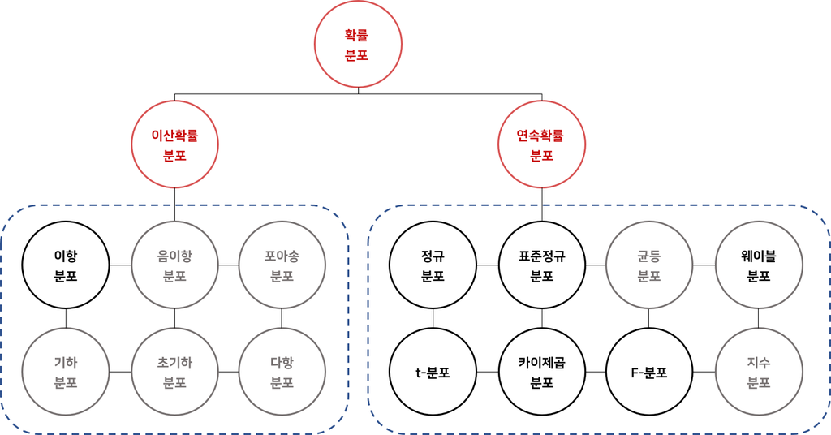

확률분포의 종류

기초적인 분포의 개념을 직관적으로 이해하기 위하여 정규분포(normal distributions)와 이항분포(binomial distributions)로부터 분위(quantiles)를 얻어내는 방법을 살펴보겠습니다.

## 정규분포 (The normal distribution)

일단 정규분포라는게 어떻게 생겨먹은 놈인지 한 번 살펴보도록 하겠습니다.

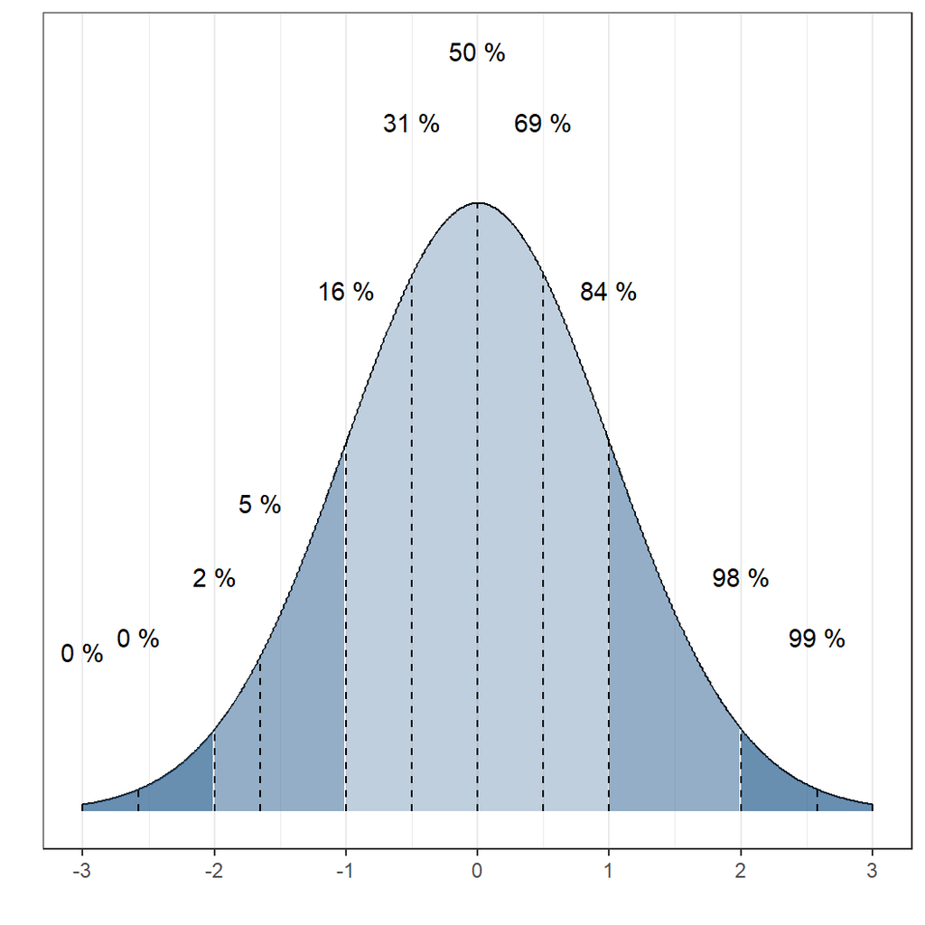

Normal distribution (Mean = 0, SD = 1)

위의 정규분포를 살펴보면, 일종의 기준점(thresholds)을 볼 수 있습니다. 즉, 전체 관측치의 약 2%가 그 기준점보다 값이 작거나 클것 등이 그런 것이죠. 나중에 가설검정과 유의수준에 대한 논의를 할 때 자세하게 살펴보도록 하겠습니다. 수학의 정석 확률과 통계 파트에서 배웠던 1.96 등과 같은 숫자들을 보게 될 것입니다. 위의 정규분포에서 좌측의 끝에 분포한 경우를 좌측꼬리(lower tail), 오른쪽 끝의 분포를 우측꼬리(upper tail)이라고 부릅니다.

```r
pnorm(70, mean = 50, sd = 10, lower.tail = TRUE)
```

```
## [1] 0.9772499
```

```r
pnorm(70, mean = 50, sd = 10, lower.tail = FALSE)
```

```
## [1] 0.02275013
```

```r
1 - pnorm(70, mean = 50, sd = 10, lower.tail = TRUE)
```

```
## [1] 0.02275013
```

첫번째 코드는 50을 평균으로 하고 10을 표준편차로 하는 정규분포가 있을 때, 그 분포에서 70이라는 숫자는 어디에 위치하는지를 묻는 것입니다.

두 번째도 동일한 의미인데, 두 식의 차이는 `lower.tail` 옵션을 어떻게 설정하느냐에 달려있습니다.

- 각 식이 도출한 결과를 보면 이해하시겠지만 근본적으로 두 식은 동일하며, 좌측에서 누적확률을 계산할 것인지 우측으로부터 계산할 것인지의 차이일 뿐입니다.
- 간단하게 말하면 첫 번째 식은 70이라는 숫자는 이 분포에서 하위 97.7%에 위치한 값이다라고 말하는 것이고 두 번째 식은 상위 2.2%라고 말하는 것입니다.
- 따라서 두 번째 식은 전체 확률에서 첫 번째 식으로 계산한 확률을 제한 값과 같으므로 세 번째의 형태로 계산할 수도 있습니다.

그렇다면 만약에 양측꼬리 확률(two-tailed probability)에서 최소한 70만큼 ‘극단적인’(extreme) 확률을 얻고 싶을 때는 어떻게 해야할까요? 이 경우는 생각을 좀 달리 해보면 됩니다. 평균을 기점으로 70은 오른쪽 끝쪽에 위치하는 셈입니다. 그만큼 왼쪽 끝에 위치한 값을 상정하고 그 값이 나올 확률을 함께 계산해주어야 합니다.

이 경우 평균 50에서 70은 20만큼 떨어져 있습니다(우측으로, + 방향). 따라서 우리는 좌측으로 20만큼 떨어진 30이 나올 확률을 함께 고려해주어야 하는 것입니다. 이러한 결과를 얻는 데는두 가지 방법이 존재합니다.

```r
## 첫 번째 방법
pnorm(70, mean = 50, sd = 10, lower.tail = FALSE) +
  pnorm(30, mean = 50, sd = 10, lower.tail = TRUE)
```

```
## [1] 0.04550026
```

```r
## 두 번째 방법
2 * pnorm(70, mean = 50, sd = 10, lower.tail = FALSE)
```

```
## [1] 0.04550026
```

그렇다면 이렇게 구한 분포에서의 누적확률 값을 가지고 분위를 구하여 보겠습니다. 마찬가지로 평균 50에 표준편차가 10인 분포를 상정합니다. 이때 사용할 함수는 `qnorm()`입니다.

```r
qnorm(0.9772499, mean = 50, sd = 10, lower.tail = TRUE)
```

```
## [1] 70.00001
```

역으로 계산한 것인데, 평균 50에 표준편차 10인 분포에서 좌측부터 앞서 구한 누적확률에 해당하는 값을 구하라는 명령입니다. 앞에서 우리가 입력한 70과 근사한 값을 얻을 수 있습니다. 근소한 차이는 소수점에 의해 발생하는 것으로 이해하시면 됩니다.

다음으로는 주어진 평균 50, 표준편차 10의 분포에서 70이라는 값이 분포에서 차지하는 밀도를 확인해보겠습니다 밀도(density)를 알아보기 위한 함수는 다음과 같습니다.

```r
dnorm(70, mean = 50, sd = 10)
```

```
## [1] 0.005399097
```

그렇다면 이번에는 정규분포에서 관측치를 무작위로 추출(draws)을 해보겠습니다. 이번에도 함수에는 70이라는 값이 사용될 것인데, 여기서 사용되는 70은 특정한 값이 아니라 추출 횟수를 의미합니다.

```r
x <- rnorm(70, mean = 50, sd = 10)
x
```

```
##  [1] 72.57308 40.05966 46.37258 44.17327 60.14351 74.55990 63.24215 54.05914
##  [9] 36.88879 63.43313 51.27676 42.93698 48.44602 40.89836 38.45322 63.27353
## [17] 61.26935 55.32106 65.52355 49.31888 57.68101 25.70053 50.03684 35.57660
## [25] 36.04556 39.71587 36.39946 56.48622 35.47841 72.15947 45.02195 55.63756
## [33] 60.69671 35.59950 63.58326 44.27626 55.46370 50.83937 46.59655 44.22666
## [41] 49.97470 38.23799 59.68103 49.14727 53.80333 37.89642 57.98342 78.17659
## [49] 44.52032 69.66339 36.60864 44.03805 53.88238 36.33232 53.21062 45.22242
## [57] 38.41020 54.88670 41.45718 59.78519 62.74681 49.02517 44.10639 48.78397
## [65] 59.74982 65.24785 55.63426 48.71448 51.23788 44.44237
```

총 70개의 값이 무작위로 추출되어 `x`라는 벡터에 담겨 있는 것을 확인할 수 있습니다.

이번에는 좀 더 구체적으로 정규분포 사례들을 살펴보겠습니다. 서로 다른 평균(mean)과 표준편차(standard deviation)를 가지는 세 개의 정규분포를 그려보겠습니다.

```r
normal5 <- rnorm(n = 10000, mean = 5, sd = 3)
normal50 <- rnorm(n = 10000, mean = 50, sd = 10)
normal20 <- rnorm(n = 10000, mean = 20, sd = 1)
```

세 함수 모두 표본의 크기는 1만 개이며, 각자 다른 평균과 표준편차를 따르는 정규분포를 가정하여 무작위로 추출된 값을 담는 벡터로 출력됩니다. 이렇게 값을 갖는 세 개의 벡터를 하나의 데이터로 합쳐보겠습니다. 간단하게 말하면 하나의 표로 합친다는 것과 같습니다.

```r
norm <- bind_rows(tibble(x = normal5, Mean = 5, SD = 3),
                  tibble(x = normal50, Mean = 50, SD = 10),
                  tibble(x = normal20, Mean = 20, SD = 1))
norm <- norm %>% mutate(
  Mean = as.factor(Mean))
```

그리고 이렇게 만들어진 데이터프레임의 평균 값을 `Factor` 자료 유형으로 변환해줍니다. 이것이 의미하는 게 뭘까요? 평균5, 평균50, 평균20을 문자열로 인식하게 하여 일종의 “이름”으로 인식하게 만드는 것입니다. 그러면 이제 이렇게 만들어진 데이터로 그래프를 그려보겠습니다.

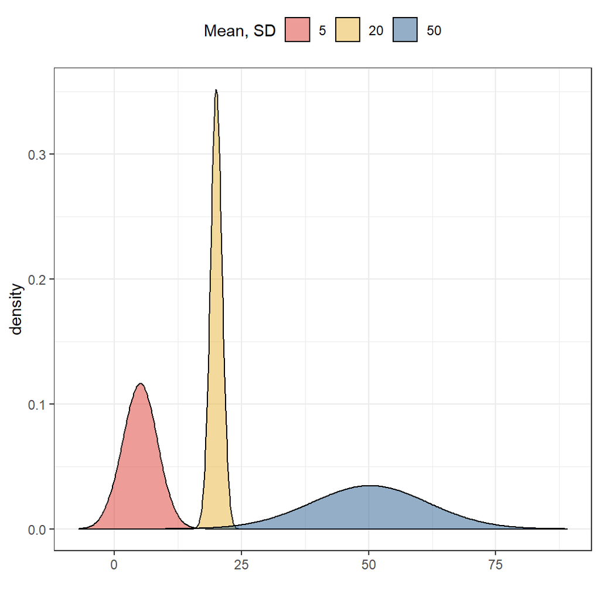

Probability Density Function of Normal Distribution

```r
ggplot(norm, aes(x = x, fill = factor(Mean))) +
  geom_density(adjust = 4, alpha = 1/2) +
  guides(color=guide_legend(title = "Mean, SD")) +
  guides(fill=guide_legend(title = "Mean, SD")) +
  scale_fill_manual(values = futurevisions("mars")) +
  scale_color_manual(values = futurevisions("mars")) +
  labs(x = "") +
  theme(legend.position = "top")
```

`ggplot2` 패키지는 **R**에서 그래프를 그리는 데 있어서 유용하게 사용됩니다. 먼저 `ggplot2` 패키지를 불러오고 나서, `ggplot(데이터프레임 이름, aes(x = x축으로 삼을 변수이름))`을 설정하면 일단 수학적으로 지정한 데이터의 변수에 대한 기본적인 작업은 진행이 됩니다.

그러나 이 단계에서는 아직 가시화(visualization)라고 할 수는 없는데, 주어진 데이터를 컴퓨팅했을 뿐이지 어떻게 가시적인 형태로 보여주라는 명령을 부여하지 않았기 때문입니다. 컴퓨터로 그림을 그려본 사람들은 이해가 쉬운데, `ggplot()`은 레이어 시스템을 이용해서, 우리가 뭔가 그려진 걸 얻고 싶을 때마다 레이어를 하나씩 추가해서 보여달라고 **R**에게 요구해야만 합니다.

### 이항분포 (Binomial distribution)

이항분포는 우리에게 `n`번의 시행에서 `k`번 성공할 확률을 보여주는 분포입니다. 단순하게 말하자면 0과 1의 값만 갖는다고 가정된 벡터가 있다고 하겠습니다. 이때 벡터의 요소의 총 개수는 100개이고 랜덤으로 0과 1 중 하나가 벡터에 들어간다고 할 수 있습니다. 이때 전체 요소의 수 100개 중 1이 뽑혔을 경우를 계산하면 결국 1을 뽑을 성공 사례의 총합을 100으로 나눔으로써, 전체 대비 성공의 확률을 구하는 것이라 할 수 있습니다. 즉, 정규분포에서와는 다르게 이항분포에서는 평균(mean)이 아니라 비율(proportion)에 초점을 맞추게 됩니다.

```r
pbinom(27, size=100, prob=0.25, lower.tail = TRUE)
```

```
## [1] 0.7223805
```

시도가 성공할 확률을 0.25라고 놓고 시행 횟수를 100번으로 가정한 경우입니다. 즉, 100번 시도했을 때 성공할 확률이 25%인 이항분포를 가지는 데, 실제로는 27번 성공했다고 한다면 누적확률에서 어느 위치에 해당하는지를 묻는 함수입니다. `lower.tail()`이 `TRUE`로 설정되어 있으므로 좌측에서부터 계산한 것입니다. 즉, 27번 성공한 것은 하위 72.2%, 상위 27.8%에 해당한다는 것을 알 수 있습니다.

```r
qbinom(0.7223805, size = 100, prob = 0.25, lower.tail = TRUE)
```

```
## [1] 27
```

이렇게 구한 누적확률로 다시금 성공 횟수를 추정해보겠습니다. 정규분포때와 거의 유사합니다. `size = 100`은 서로 독립적인 사건의 시행, 즉 베르누이 시행(Bernoulli trials)의 횟수를 의미합니다. 그렇다면 100번 시도했을 때 27번 성공할 정확한 확률을 구해보겠습니다.

```r
dbinom(27, size=100, prob=0.25)
```

```
## [1] 0.08064075
```

```r
choose(100, 27)*.25^27*(1-.25)^(100-27)
```

```
## [1] 0.08064075
```

두 가지 방법으로 구할 수 있는데, 첫 번째는 **R**에 내장된 기본 함수인 `dbinom()`으로 구하는 것입니다. 두 번째는 `choose()` 함수를 이용해서 구하는 것입니다. 개인적으로는 `dbinom()` 함수가 있는데 굳이 `choose()` 함수 사용법까지 알아야 하나 싶기는 합니다. 그러나 `choose()` 함수로 보여지는 식이 좀 더 직관적으로 이해하기에는 도움이 됩니다.

```r
rbinom(27, size=100, prob=0.25)
```

```
##  [1] 31 21 17 25 30 28 23 27 25 24 30 31 24 27 27 27 22 17 29 21 27 27 10 22 26
## [26] 24 28
```

```r
sd(rbinom(27, size=100, prob=0.25))
```

```
## [1] 3.772747
```

다시 한 번, `n`번의 독립적인 베르누이 사건을 시행할 때, `k`번 성공할 확률을 구하는 이항분포로 실습해보겠습니다. 구체적으로 모집단의 성공 확률을 `p`, 모집단의 크기를 `n`으로 특정하겠습니다.

```r
binom10 <- rbinom(n = 10000, p = .5, size = 10)
binom50 <- rbinom(n = 10000, p = .5, size = 50)
binom100 <- rbinom(n = 10000, p = .5, size = 100)
```

정규분포와 다르지는 않습니다. 다만 여기서의 `size`는 전체 동전을 던지는 횟수로 이해하면 되고 10,000은 그렇게 동전을 10번, 50번, 100번 던지는 걸 10,000번 반복한다는 의미라고 할 수 있습니다. 그럼 이제 마찬가지로 하나의 데이터프레임으로 세 번의 시도(`binom10`, `binom50`, `binom100`)의 결과를 합쳐주고 그래프를 그려보겠습니다.

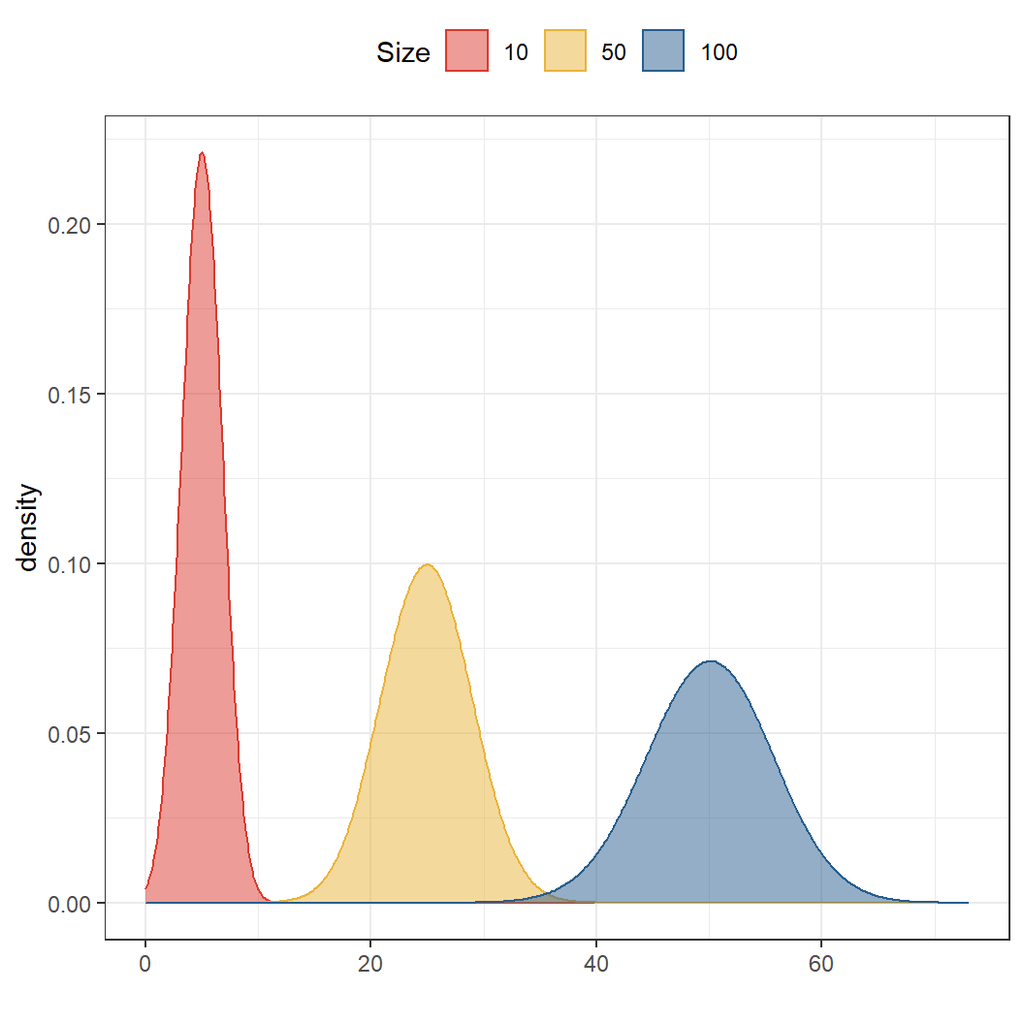

Probability Mass Function of Binomial Distribution

```r
binom <- bind_rows(tibble(k = binom10, Size = 10),
                   tibble(k = binom50, Size = 50),
                   tibble(k = binom100, Size = 100)) %>%
  mutate(Size = as.factor(Size))

ggplot(binom, aes(x = k)) +
  geom_density(aes(group = Size, color = Size, fill = Size),
               adjust = 4, alpha = 1/2) +
  scale_color_manual(values = futurevisions("mars")) +
  scale_fill_manual(values = futurevisions("mars")) +
  labs(x = "") +
  theme(legend.position = "top")
```

### 포와송 분포 (Poison distribution)

이 포스팅은 주로 **R** 코드에 관한 것이기 때문에 분포에 대한 수리통계적인 설명은 가급적 피하도록 하겠습니다. 포와송 분포는 고정된 대규모 모집단(fixed large population)에서 짧은 시간에 걸쳐서 희소한 사건(rare events)의 발생 횟수를 추정하는 데 용이한 분포입니다.

포와송 분포에서 그 희소한 사건의 발생 확률은 시간 단위 별 발생의 평균 횟수로 나타나며 그리스어 람다(`Lambda`, $\lambda$)로 표기됩니다. 람다는 평균과 분산을 결정합니다.

포와송 분포의 확률을 이용해서 우리는 단일 시간 단위에서 `k`라는 희소한 사건을 정확하게 관측할 확률을 기술할 수 있습니다. 나머지는 앞의 정규분포랑 이항분포에서 했던 코드를 기계적으로 반복해서 살펴보는 것과 같습니자. 단, 포와송 분포에서 코드 중에는 이전과 다른 부분이 있으니 그 점만 유의하면 될 것 같습니다.

```r
pois1 <- rpois(n = 10000, lambda = 1)
pois2 <- rpois(n = 10000, lambda = 2)
pois5 <- rpois(n = 10000, lambda = 5)
pois20 <- rpois(n = 10000, lambda = 20)
pois <- tibble(Lambda.1 = pois1,
               Lambda.2 = pois2,
               Lambda.5 = pois5,
               Lambda.20 = pois20)
pois # 처음 만들어진 pois 데이터
```

| Lambda.1 | Lambda.2 | Lambda.5 | Lambda.20 |
| --- | --- | --- | --- |
| 0 | 6 | 3 | 28 |
| 1 | 2 | 12 | 19 |
| 0 | 0 | 5 | 23 |
| 0 | 1 | 4 | 17 |
| 4 | 2 | 3 | 29 |
| 1 | 2 | 5 | 28 |
| 0 | 3 | 3 | 17 |
| 1 | 5 | 2 | 12 |
| 0 | 1 | 9 | 27 |
| 1 | 2 | 5 | 27 |

[output cut: 9990 more lines]

```r
pois <- pois %>% tidyr::gather("Lambda", "x")
pois # gather 함수를 이용해 wide -> long으로 바뀐 데이터
```

| Lambda | x |
| --- | --- |
| Lambda.1 | 0 |
| Lambda.1 | 1 |
| Lambda.1 | 0 |
| Lambda.1 | 0 |
| Lambda.1 | 4 |
| Lambda.1 | 1 |
| Lambda.1 | 0 |
| Lambda.1 | 1 |
| Lambda.1 | 0 |
| Lambda.1 | 1 |

[output cut: 9990 more lines]

```r
pois <- pois %>% mutate(
  Lambda = Lambda %>%
    str_remove("Lambda.") %>%
    parse_factor(.,
                 levels = c("1", "2", "5", "20"),
                 ordered = T, include_na = F)
)
pois # Lambda라는 문자열을 지우고 숫자만 factor 로 변환
```

| Lambda | x |
| --- | --- |
| 1 | 0 |
| 1 | 1 |
| 1 | 0 |
| 1 | 0 |
| 1 | 4 |
| 1 | 1 |
| 1 | 0 |
| 1 | 1 |
| 1 | 0 |
| 1 | 1 |

[output cut: 9990 more lines]

처음 만든 `pois` 데이터에서 `tidyr`의 `gather()`를 이용해서 `Lambda`라는 변수 아래에 1, 2, 5, 20의 라벨을 길게(long-shape) 합쳤습니다. 그리고 마지막으로는 `Lambda` 변수의 문자열 `Lambda.`을 제외한 라벨 숫자만 남겨놓은 것입니다. 결과적으로 `Lambda` 변수에는 각 `Lambda` 값이 얼마였는지를 나타내는 순위를 가진 요인형 변수값만 남았습니다. 이렇게 만들어진 포와송 분포의 값들을 하나의 그래프로 만들어서 시각화해보도록 하겠습니다.

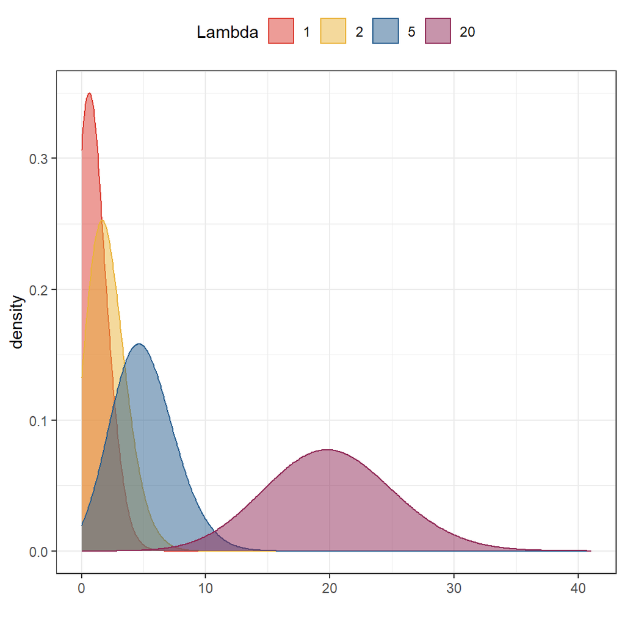

Probability Mass Function of Poisson Distribution

```r
ggplot(pois, aes(x = x)) +
  geom_density(aes(group = Lambda,
                   color = Lambda,
                   fill = Lambda),
               adjust = 4, alpha = 1/2) +
  scale_color_manual(values = futurevisions("mars")) +
  scale_fill_manual(values = futurevisions("mars")) +
  labs(x = "") +
  theme(legend.position = "top")
```

### 음이항 분포 (Negative Binomial Distribution)

음이항 분포는 `n`번째 시도에서 `k`번째에 성공할 확률을 보여줍니다. 음이항 분포는 다음과 같은 네 조건이 충족될 때 유용합니다.

1. 모든 시도는 독립적이다.
2. 각 시도의 결과는 성공 혹은 실패로 구분될 수 있다.
3. 성공 확률 (`p`)은 각 시도마다 동일하다.
4. 마지막 시도는 항상 성공이어야만 한다.

여기서 보면 알 수 있듯이, 처음 세 조건은 이항분포와 동일합니다. 세 개의 음이항 분포 결과를 계산하여 세 개의 벡터로 저장하겠습니다. 그리고 이걸 마찬가지로 하나의 데이터로 합칩니다.

```r
nbinom1 <- rnbinom(n = 10000, p = .3, size = 1)
nbinom5 <- rnbinom(n = 10000, p = .3, size = 5)
nbinom10 <- rnbinom(n = 10000, p = .3, size = 10)
nbinom <- bind_rows(tibble(x = nbinom1, Size = 1),
                    tibble(x = nbinom5, Size = 5),
                    tibble(x = nbinom10, Size = 10)) %>%
  mutate(Size = as.factor(Size))
```

포와송이랑 이항분포에서 사용했던 함수들과 거의 유사합니다. 이렇게 만들어진 그래프는 다음과 같습니다.

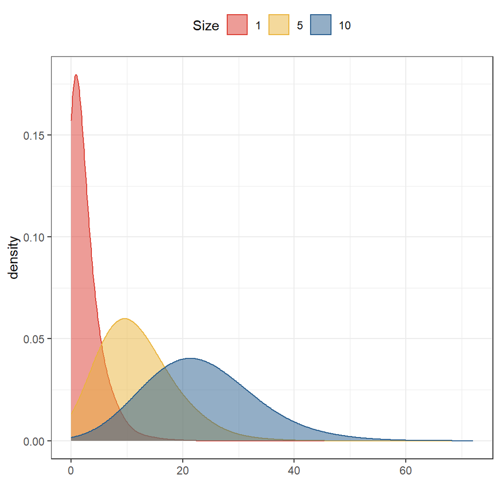

Probability Mass Function of Negative Binomial Distribution

```r
ggplot(nbinom, aes(x = x)) +
  geom_density(aes(group = Size, color = Size, fill = Size),
               adjust = 4, alpha = 1/2) +
  scale_color_manual(values = futurevisions("mars")) +
  scale_fill_manual(values = futurevisions("mars")) +
  labs(x = "") + theme(legend.position = "top")
```

### F 분포 (F Distribution)

`rf()`를 통해서 F 분포에서 무작위로 10,000개의 값을 서로 다른 자유도를 이용하여 추출하여 네 개의 벡터에 저장합니다. 이제는 아시겠지만 `rf()`의 `r`은 random을 의미합니다.

```r
fa <- rf(n = 10000, df1 = 1, df2 = 50)
fb <- rf(n = 10000, df1 = 5, df2 = 100)
fc <- rf(n = 10000, df1 = 50, df2 = 50)
fd <- rf(n = 10000, df1 = 50, df2 = 500)
f <- bind_rows(tibble(x = fa, DF1 = 5, DF2 = 5),
               tibble(x = fb, DF1 = 5, DF2 = 10),
               tibble(x = fc, DF1 = 10, DF2 = 5),
               tibble(x = fd, DF1 = 10, DF2 = 10))
```

이렇게 만들어진 데이터의 결과는 그림과 같습니다. 그리고 이제 `x` 값이 6보다 작거나 같은 경우로 하위 데이터를 만듭니다. 왜냐하면 굉장히 극단적인 수치들이 희소한 확률로 있기 때문에 그냥 그래프를 그리면 집단 별 차이를 보기가 조금 힘들 수도 있기 때문입니다. 그리고 전체 자유도를 지정해줄 것입니다. 자세한 내용은 나중에 `F-distribution`을 언급할 때 설명하도록 하겠습니다.

[figure not shown]

Probability Density Function of F Distribution

```r
f <- f %>% dplyr::filter(x <= 6) %>%
  mutate(DF = DF1 * 100 + DF2) %>%
  mutate(DF = as.factor(DF))

ggplot(f, aes(x = x)) +
  geom_density(aes(color = DF, fill = DF),
               adjust = 4, alpha = 1/2) +
  guides(color=guide_legend(title = "DF1, DF2")) +
  guides(fill=guide_legend(title = "DF1, DF2")) +
  scale_color_manual(
    values = futurevisions("mars"),
    labels = c("1, 50", "5, 500", "50, 50", "50, 500")) +
  scale_fill_manual(
    values = futurevisions("mars"),
    labels = c("1, 50", "5, 500", "50, 50", "50, 500"))
```

`DF1`이랑 `DF2`를 합쳐준다는 것은 F-분포의 특징 때문인데, 간단하게 말하자면 t-분포와 다르게 F-분포는 분자, 분모에 자유도가 하나씩 즉 2개가 필요하기 때문입니다.

오늘 포스팅한 내용 중에서는 처음 두 분포, 정규분포와 이항분포에 대해서는 숙지할 필요가 있고 나머지 분포들은 추후에 다시 다룰 기회가 있을 것이라고 생각합니다. 사실 분포는 엄청 많습니다: 웨이블, 토빗… 뭐 여럿 있기 때문에 다 외우는 것은 어렵고 여기서는 단지 R-code로 구현하는 방법을 러프하게 살펴보았다고 할 수 있을 것입니다.

그리고 `ggplot()`은 손에 익도록 연습하는 것이 좋습니다. **R**의 장점 중 하나는 여타의 통계툴들에 비해 그래프 기능이 뛰어나다는 것입니다. `ggplot()`은 **R**이 그러한 명성을 얻게 해 준 공신 중 하나라고 할 수 있습니다.